# Test a Perceptual Phenomenon.v2

### Analyzing the Stroop Effect

Perform the analysis in the space below. Remember to follow [the instructions](https://docs.google.com/document/d/1-OkpZLjG_kX9J6LIQ5IltsqMzVWjh36QpnP2RYpVdPU/pub?embedded=True) and review the [project rubric](https://review.udacity.com/#!/rubrics/71/view) before submitting. Once you've completed the analysis and write-up, download this file as a PDF or HTML file, upload that PDF/HTML into the workspace here (click on the orange Jupyter icon in the upper left then Upload), then use the Submit Project button at the bottom of this page. This will create a zip file containing both this .ipynb doc and the PDF/HTML doc that will be submitted for your project.

```python
# load packages
import pandas as pd
import scipy.stats as stats
import matplotlib.pyplot as plt

%matplotlib inline
```

```python
# load data and get some information about it
df = pd.read_csv('stroopdata.csv')

print("data dimensions", df.shape)
df.head()
```

```
data dimensions (24, 2)
```

|  | Congruent | Incongruent |
| --- | --- | --- |
| 0 | 12.079 | 19.278 |
| 1 | 16.791 | 18.741 |
| 2 | 9.564 | 21.214 |
| 3 | 8.630 | 15.687 |
| 4 | 14.669 | 22.803 |

```python
df.info()
```

```
<class 'pandas.core.frame.DataFrame'>
RangeIndex: 24 entries, 0 to 23
Data columns (total 2 columns):
Congruent      24 non-null float64
Incongruent    24 non-null float64
dtypes: float64(2)
memory usage: 464.0 bytes
```

(1) What is the independent variable? What is the dependent variable?

Here, we have an experiment set with two treatments (congruent and incongruent), in which the researcher estimated the time a participant took to distinguish the color of words. We have the dependent (or response) variable as the time of response by the participants. The independent variable is the one clearly established by the researcher in order for her/him to possibly explain the response variable. That is, the independent (explanatory) variable are the treatments Congruent and Incongruent.

(2) What is an appropriate set of hypotheses for this task? Specify your null and alternative hypotheses, and clearly define any notation used. Justify your choices.

In my opinion, the perception of color by our brains is supported by different visual cues, and when someone reads a word with the exact reference to its font color, the brain is somehow helped and therefore the response time should be faster than if it just "sees" the color without any other reference to it. Consequently, when the color is dismatched with the name, I would expect the brain to be induced to a confusion and error.

Therefore, the null hypothesis would be the scenario where we do not find significant differences between both treatments (variables Congruent and Incongruent). More specifically, since we expect that the Congruent treatment would produce lower times, we can say that the null hypothesis is the case where Congruent and Incongruent are equal or Congruent might even be larger than Incongruent, whereas the alternative hypothesis is the scenario where Congruent is lower than Incongruent.

Hence, we have the hypothesis below: \begin{equation} (H_{0}) \text{ Null hypothesis}: \mu_{c} - \mu_{i} >= 0 \end{equation}

\begin{equation} (H_{1}) \text{ Alternative hypothesis}: \mu_{c} - \mu_{i} < 0 \end{equation}

where $\mu_{c}$ is the population mean time needed to answer when color and word correctly match (Congruent), and $\mu_{i}$ is the mean population time needed to answer when color and word do not match (Incongruent).

To compare these two samples, we should use a **paired T-test**, given that sample size is very small and the results come from the same participants (they took both treatments, and therefore results are not entirely independent). Moreover, we want to test whether Congruent is indeed lower than Incongruent (**one-sided**).

(3) Report some descriptive statistics regarding this dataset. Include at least one measure of central tendency and at least one measure of variability. The name of the data file is 'stroopdata.csv'.

```python
# Average time response per treatment
mean_c = df['Congruent'].mean()
mean_i = df['Incongruent'].mean()
# Variance of time responses per treatment
variance_c = df['Congruent'].var()
variance_i = df['Incongruent'].var()
# Standard variation of time responses per treatment
std_c = df['Congruent'].std()
std_i = df['Incongruent'].std()
```

For the "Congruent" and "Incongruent" groups, I calculated the mean as a measure of central tendency, and variance and standard variation as measures of variability. Results are reported below.

```python
print("Congruent group")
print("mean:", round(mean_c,2))
print("variance:", round(variance_c,2))
print("standard variation:", round(std_c,2))
print("")
print("Incongruent group")
print("mean:", round(mean_i,2))
print("variance:", round(variance_i,2))
print("standard variation:", round(std_i,2))
```

```
Congruent group
mean: 14.05
variance: 12.67
standard variation: 3.56

Incongruent group
mean: 22.02
variance: 23.01
standard variation: 4.8
```

(4) Provide one or two visualizations that show the distribution of the sample data. Write one or two sentences noting what you observe about the plot or plots.

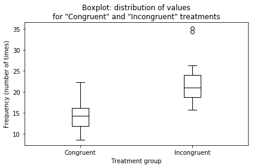

```python
# Plot 1: boxplots for treatment groups
df[['Congruent', 'Incongruent']].plot(kind='box', color = 'black')
plt.title('Boxplot: distribution of values\nfor "Congruent" and "Incongruent" treatments')
plt.ylabel('Frequency (number of times)')
plt.xlabel('Treatment group')
plt.tight_layout()
plt.show;
```

The "Congruent" group (left) and the "Incongruent" group (right) apparently show different values. As we can observe in the first graph (boxplots), we notice the spread of the data with two outliers present in the Incongruent group, particularly. More than half of the data for Congruent laid below the values of Incongruent.

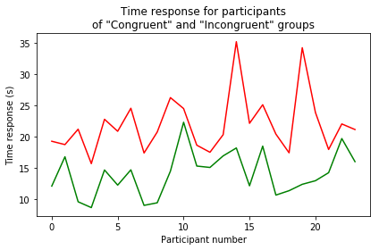

```python
# Plot 2: Line plot for treatment groups
plt.plot(df['Congruent'], '-', color='green')
plt.plot(df['Incongruent'], '-', color='red')
plt.title('Time response for participants\nof "Congruent" and "Incongruent" groups')
plt.ylabel('Time response (s)')
plt.xlabel('Participant number')
plt.tight_layout()
plt.show();
```

When we look at the line plot for both groups, we notice that the red line (Incongruent) always stayed above the green line (Congruent), and showed two higher peaks (the two outliers), suggesting that "Congruent" has lower response time than "Incongruent".

(5) Now, perform the statistical test and report your results. What is your confidence level or Type I error associated with your test? What is your conclusion regarding the hypotheses you set up? Did the results match up with your expectations? **Hint:** Think about what is being measured on each individual, and what statistic best captures how an individual reacts in each environment.

According to my websearch, the assumptions for a T-test are:

- The scale of measurement applied to the data collected follows a continuous or ordinal scale.
- The data is collected from a representative, randomly selected portion of the total population.
- The data, when plotted, results in a normal distribution, bell-shaped distribution curve.
- A reasonably large sample size is used. A larger sample size means the distribution of results should approach a normal bell-shaped curve.
- Homogeneity of variance. Homogeneous, or equal, variance exists when the standard deviations of samples are approximately equal.

The data is clearly continuous and I assume that it was well collected, because it was performed by a serious research group. Thus, the first two assumptions seem to hold. The data is not extremely large, but it is over 20 observations, so assumption four may also be respected (reasonable sample size). My calculations do not show that variances are exactly the same, but standard deviations are relatively close between of ca. 3 and 5. This leaves us with the third assumption still to be checked. Let's test the assumptions of a parametric data (normality), so that we know if we can use a normal T-test

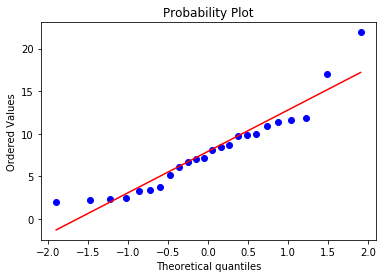

```python
# Difference between groups
df['diff'] = df['Incongruent'] - df['Congruent']
# Q-Qplot to test the normality of differences between the two samples
stats.probplot(df['diff'], plot= plt);
```

If we observe the Q-Qplot above we see that the data fits to a normal distribution (red line), although some data still fall outside the fit. Given that this data is not large, it is naturally hard to find a well normally distributed data anyway.

In summary, we may say that the assumptions for a T-test are all, although not perfectly, respected. That supports us to follow on in the analysis.

```python
# T-test
t_test = stats.ttest_rel(df['Incongruent'], df['Congruent'])
print("T-test output")
print("t-statistic:", t_test.statistic)
print("p-value:", t_test.pvalue)
```

```
T-test output
t-statistic: 8.020706944109957
p-value: 4.103000585711178e-08
```

```python
# Calculation of p-value for one-sided hypothesis:
P = round(t_test.pvalue/2, 4)
print("p-value:", P)
print("Reject Null hypothesis:", P < 0.001)
```

```
p-value: 0.0
Reject Null hypothesis: True
```

With this, we can reject the null hypothesis and accept the idea that time response for "Congruent" is indeed lower than "Incongruent". The result match perfectly with my expectations and visual representations of the data described previously.

(6) Optional: What do you think is responsible for the effects observed? Can you think of an alternative or similar task that would result in a similar effect? Some research about the problem will be helpful for thinking about these two questions!

Probably our brains work receiving different environmental cues and processing them all together. In this sense, visual stimuli add up as information so that the brain can "take decisions". One similar example could therefore be the representation of shape and sizes of objects together with their representing words, such as big/small blocks with different sizes. In my opinion the results would also be similar if this experiment used comparable combinations, instead of colors.